# Data Visualization Part 2: Student Project

The final project consists of visualization and text exercises. For the visualization exercises the following steps are required:

- perform all exercises in a Jupyter notebook
- add your matriculation number to the Jupyter notebook!
- write Python code to visualize the given data (see detailed instructions below)
- comment your code to describe what your code does
- recreate the the shown example figures using the provided data
- export the final notebook to an html and upload it to iLearn

## 1: Visualization Exercises

Three alternative visualizations of the same artificial data shall be re-created. All three visualizations show the same fictitious genomic annotations together with fictitious RNA binding protein data in different ways. Recreate each of the shown versions. Two different datasets are provided for this task:

- *10_project_data_annotations.csv*
- *10_project_data_signals.csv*

The *10_project_data_annotations.csv* file contains fictitious genomic information as visualized in all bottom panels of the example plots. Each horizontal line represents a transcript. A transcript can contain multiple exons (grey rectangles). Transcripts can be located on the '+' or on the '-' strand of the DNA.

*10_project_data_signals.csv* contains fictitious signals of four RNA binding proteins (P1, P2, P3, P4).

### 1.1: Version 1

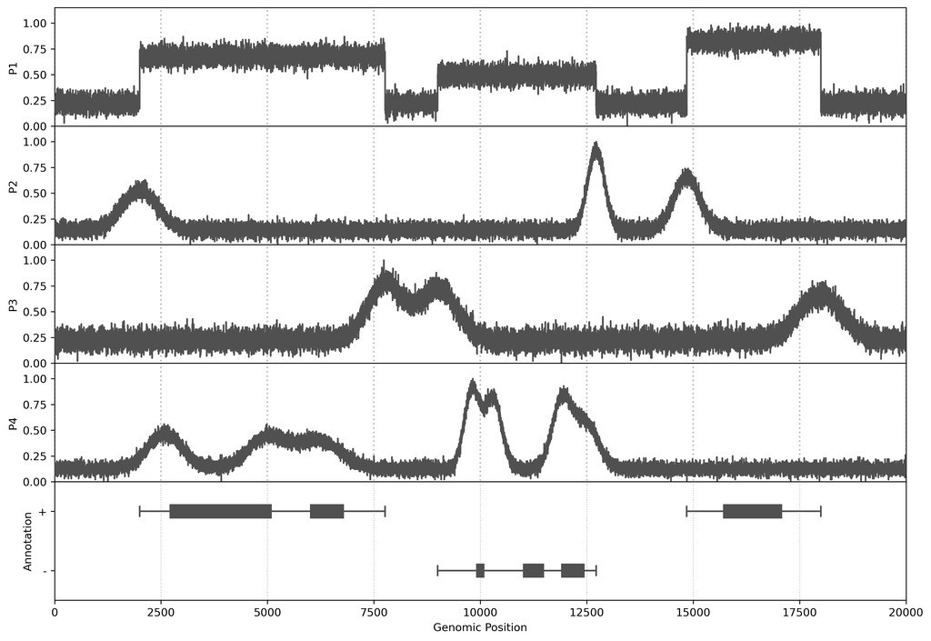

### 1.2: Version 2

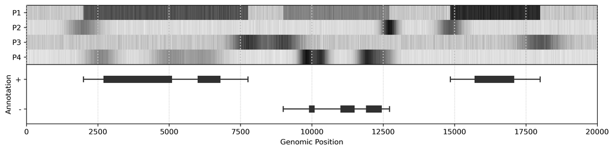

### 1.3: Version 3

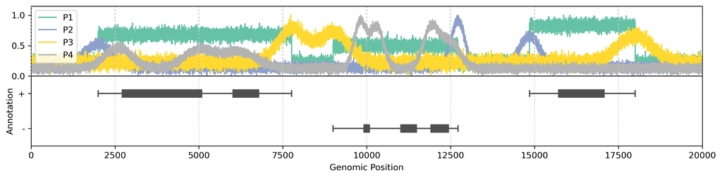

### 1.4: Discussion

Discuss the pros and cons between the three different visualization approaches.

## 2: Visualization Exercises

In this task, two additional plots shall be added to create a bigger figure. Recreate the shown figure. Note, that the bottom part of the figure is one of your solutions from the first exercise. Two additional datasets are provided:

- *10_project_data_scatter.csv* contains the data needed to create the shown scatter plot
- *10_project_data_barplot.csv* contains the data needed to create the shown bar plot.

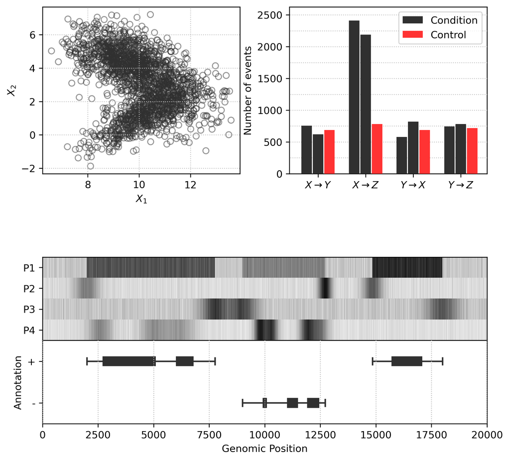

## 3: Text Exercise

Summarize the article *'Pencil and paper'* by Wong & Kjaergaard. What are the key points? Do not copy and paste from the article. Summarize in your own words.